# Assignment 2

Ewelina Plachimowicz

4/6/2022

## 1. A brief description of the show

*Suits* is an American television drama series created by *Aaron Korsh*, which premiered on June 23, 2011 on the *USA Network*. It revolves around *Mike Ross* (*Patrick J. Adams*), who begins working as a law associate for *Harvey Specter* (*Gabriel Macht*), despite never attending law school. The show focuses on Harvey and Mike managing to close cases, while maintaining Mike’s secret.

The series was renewed for an eighth season on January 30, 2018. In January 2019, the series was renewed for a ninth and final season which premiered on July 17, 2019. During the course of the series, 134 episodes of *Suits* aired over nine seasons, between June 23, 2011, and September 25, 2019.

## 3. Basic statistics summary

**Series overview:**

| Season |  | Episodes |  | Originally aired |  |
| --- | --- | --- | --- | --- | --- |
|  |  |  |  | First aired | Last aired |
|  | 1 | 12 |  | June 23, 2011 | September 8, 2011 |
|  | 2 | 16 |  | June 14, 2012 | February 21, 2013 |
|  | 3 | 16 |  | July 16, 2013 | April 10, 2014 |
|  | 4 | 16 |  | June 11, 2014 | March 4, 2015 |
|  | 5 | 16 |  | June 24, 2015 | March 2, 2016 |
|  | 6 | 16 |  | July 13, 2016 | March 1, 2017 |
|  | 7 | 16 |  | July 12, 2017 | April 25, 2018 |
|  | 8 | 16 |  | July 18, 2018 | February 27, 2019 |
|  | 9 | 10 |  | July 17, 2019 | September 25, 2019 |

**Audience measurement:**

| Season |  | Episode number |  |  |  |  |  |  |  |  |  |  |  |  |  |  |  |
| --- | --- | --- | --- | --- | --- | --- | --- | --- | --- | --- | --- | --- | --- | --- | --- | --- | --- |
|  |  | 1 | 2 | 3 | 4 | 5 | 6 | 7 | 8 | 9 | 10 | 11 | 12 | 13 | 14 | 15 | 16 |
|  | 1 | 4.64 | 3.89 | 4.53 | 4.38 | 4.38 | 4.44 | 4.03 | 3.96 | 4.45 | 3.82 | 3.96 | 3.47 | N/A |  |  |  |
|  | 2 | 3.47 | 3.80 | 3.88 | 3.70 | 3.72 | 3.89 | 3.41 | 3.42 | 4.00 | 4.48 | 3.57 | 3.75 | 3.36 | 3.07 | 2.90 | 3.20 |
|  | 3 | 2.93 | 2.89 | 2.48 | 2.99 | 2.79 | 2.76 | 2.79 | 3.52 | 2.95 | 3.16 | 2.28 | 2.28 | 2.35 | 2.53 | 2.50 | 2.40 |
|  | 4 | 2.50 | 2.65 | 2.76 | 2.42 | 2.33 | 2.70 | 2.81 | 2.59 | 2.59 | 2.76 | 1.87 | 1.67 | 1.46 | 1.70 | 1.80 | 1.55 |
|  | 5 | 2.13 | 2.27 | 2.16 | 2.38 | 2.10 | 2.16 | 2.08 | 2.31 | 2.30 | 2.34 | 1.74 | 1.51 | 1.71 | 1.58 | 1.73 | 1.71 |
|  | 6 | 1.85 | 1.65 | 1.78 | 1.81 | 1.51 | 1.68 | 1.83 | 1.88 | 1.87 | 1.92 | 1.37 | 1.53 | 1.28 | 1.21 | 1.25 | 1.13 |
|  | 7 | 1.40 | 1.36 | 1.41 | 1.41 | 1.29 | 1.47 | 1.35 | 1.51 | 1.64 | 1.68 | 1.18 | 1.06 | 0.95 | 0.99 | 1.09 | 1.07 |
|  | 8 | 1.27 | 1.18 | 1.16 | 1.09 | 1.15 | 1.22 | 1.13 | 1.30 | 1.07 | 1.08 | 0.82 | 0.91 | 0.77 | 0.78 | 0.69 | 0.74 |
|  | 9 | 1.04 | 1.04 | 0.94 | 1.00 | 0.96 | 1.05 | 1.07 | 0.97 | 0.96 | 0.86 | N/A |  |  |  |  |  |

*Performed by Nielsen Media Research*

## 4. Viewership over time

Below, you can find a groph with **viewership of the show over time**, for all episodes:

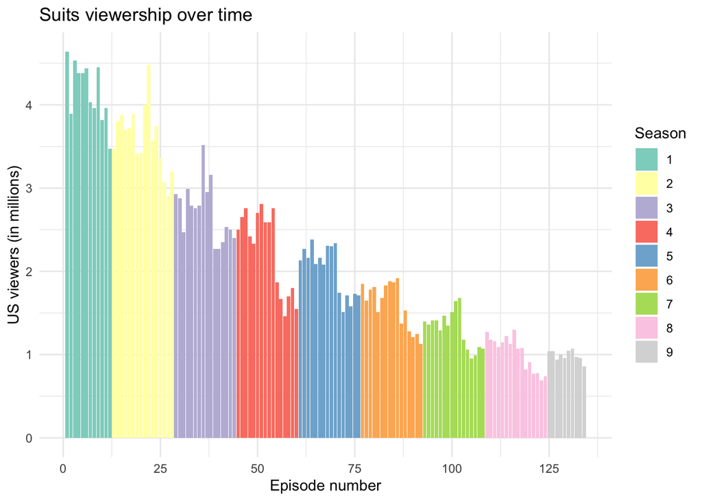

## 5. Episode-to-episode changes in viewership

Below, you can find a graph with **changes in viewership** of the show over time (in episode-to-episode format:

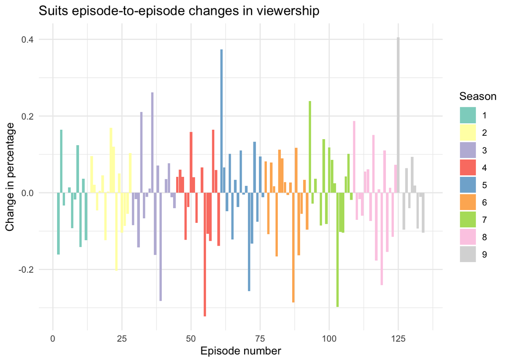

## 6. Description of the observed changes

From the chart in point 4, it’s easy to see that *Suits’* viewership is **declining with each season** - in the case of Season One, the series attracted around **4 million** viewers per episode. Already in season five, this number was twice as low - around **2 million** viewers per episode. Last season drew approximately **1 million** viewers per episode. Referring to the graph in Section 5, viewership changes for the episode-to-episode comparison appear to be **similar between seasons**. The biggest change was recorded in the first episode of the last season - about **40% increase** in viewership compared to the last episode of the 8th season.